# Revisions to Cui, Jensen and Macdonald (2020)

Ryan Gross

This document provides a description of the incorrect distance calculations made in Cui, Jensen and Macdonald (2020), including the updated tables and figures using the correct calculations.

## Description of incorrect distance calculations

There are 4 main elements used in the paper that use longitude-latitude (x,y) coordinates: vacant lots (as a single point designating the center of the lot), land-zoning designations (as an outline of a shape made up of many points), business (as a single point at the address of the business), and crimes (as a single point at the location of the crime). These coordinates themselves are not the problem; however, computing distances between the coordinates is where the issue occurred. Thus, I investigated the code for generating the land-use, business, and crime variables to determine which ones were impacted.

### Land-use variables

The land-use variables were calculated correctly. These variables (one for each land-use type) were created by intersecting a given land-zoning shape with the circle drawn at a 200 meter radius from a vacant lot, and calculating the proportion of the circle that contains the given land-zoning. For this calculation, the authors used the `Shapely` library in Python, which follows the (longitude, latitude) convention that all coordinates in the data were defined by. Thus, these calculations were carried out correctly, and so none of the land-use variables need to be fixed.

### Business and crime variables

However, the business variables (both business presence and business count) and crime count variable were computed incorrectly. For these variables, the authors used the `GeoPy` library in Python–specifically the `geopy.distance` function–which takes in points as (latitude, longitude) to compute distances between two points. However, they continued using the (longitude, latitude) convention, and thus the points being passed into the `geopy.distance` function were flipped (in terms of the map of the world). On a Cartesian coordinate system, this would not be a problem, as the distance from (x1, y1) to (x2, y2) is the same as the distance from (y1, x1) to (y2, x2). However, on the map of the world (where longitude corresponds to x and latitude to y), these distances are not the same. This is because the distance between degrees of longitude at the equator is much greater than the distance between degrees of longitude at the poles. So, by flipping the longitude-latitude coordinates, the distances passed into `geopy.distance` were based on coordinates somewhere in Antarctica, rather than in Philadelphia. Thus, all of the distances calculated are scaled down from the true distances; this caused the variables representing crime counts, business counts, and business presence indicators to all be scaled up from their true values.

In my revision of the code, I correctly specified the coordinates for the geopy.distance function for generating these variables and re-ran the remainder of the code to obtain updated results. Figures and tables that don’t involve the business or crime variables won’t be affected, and so these were not included. Since the crime and business variables were generally scaled by an equal amount, the affected results do not change in a surprising way, and most conclusions made from these results remain the same. However, there are a few notable discrepancies with the original results, and these are noted in the next section.

## Revised tables and figures

### Figure 1

**Stays the same as the original.** All land-use attributes were calculated correctly. All other attributes here are based on the census block level, which involved no distance calculations.

### Table 1

| Crime Category | Pre-Greening Crime Rate | DID Estimate | Standard Error | T-stat | p-value | DID Estimate as a % |
| --- | --- | --- | --- | --- | --- | --- |
| Serious | 21.8 | -0.00475 | 0.146 | -0.0326 | 9.74e-01 | -0.0218 |
| Other | 78.8 | -2.61000 | 0.357 | -7.3100 | 3.19e-13 | -3.3100 |
| Total | 101.0 | -2.61000 | 0.420 | -6.2100 | 5.62e-10 | -2.6000 |

**Notable difference from the original.** At the 200 meter level, the effect of vacant lot greening on Serious crimes is no longer significant. The rate of Serious crimes after greening still decreased, but only by a minimal and nonsignificant amount. However, the effect on Other crimes remained signficant (in fact, it even shows a stronger effect from the original results) and, most importantly, the Total crime effect remained significant.

We will observe a similar change in Table S3, which looks at these same effects at a 100m radius. However, based on Table S4, at the 500m radius all 3 crime effects remain significant.

Assuming we can interpret these results causally, this tells us that lot greening does not significantly impact serious (i.e. violent) crimes directly around the area of lot greening. But, other (i.e. nonviolent) crimes are reduced by lot greening and the overall measure of crime is indeed reduced by lot greening. Moreover, if we instead look a little farther out from the lot, serious crimes do appear to be reduced by lot greening.

### Figure 2

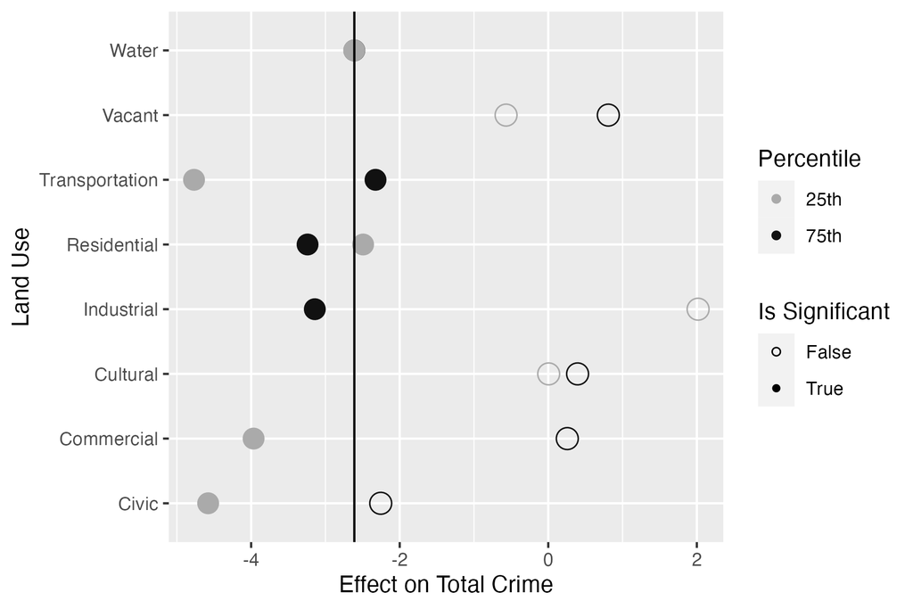

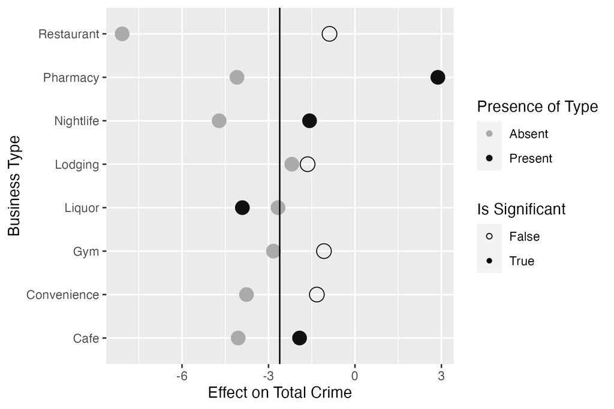

**Minor differences from the original.** With the updated results, there are some minor differences in the influence of land-use types and business presence around a vacant lot on crime rates due to lot greening.

In terms of land-use, we still see that areas with high residential, high industrial, and low transportation levels all show an increased reduction of crime from lot greening. However, it now appears that *low* civic and commercial levels (as opposed to *high* levels in the original results) lead to greater reductions of crime from lot greening.

In terms of business presence, we now see that the presence of liquor stores and the absence of pharmacies and nightlife and cafes lead to an increased reduction of crime from lot greening. [As an aside: Given that liquor stores are associated with higher crime (based on Humphrey et al. 2019), this is interesting/makes sense that greening a lot near a liquor store will have a greater impact on reducing crime than greening a lot near a different type of business.]

### Figure S1

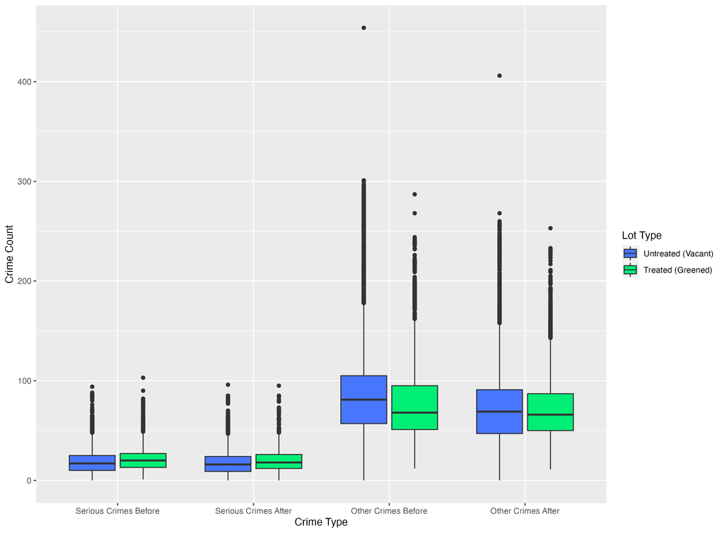

**Mostly the same as the original**, except with scaled down crime counts, as expected.

### Figure S2

**Stays the same.** All attributes here are based on the census block level, which involved no distance calculations.

### Figure S3

**Stays the same.** All land use attributes were calculated correctly.

### Figure S4

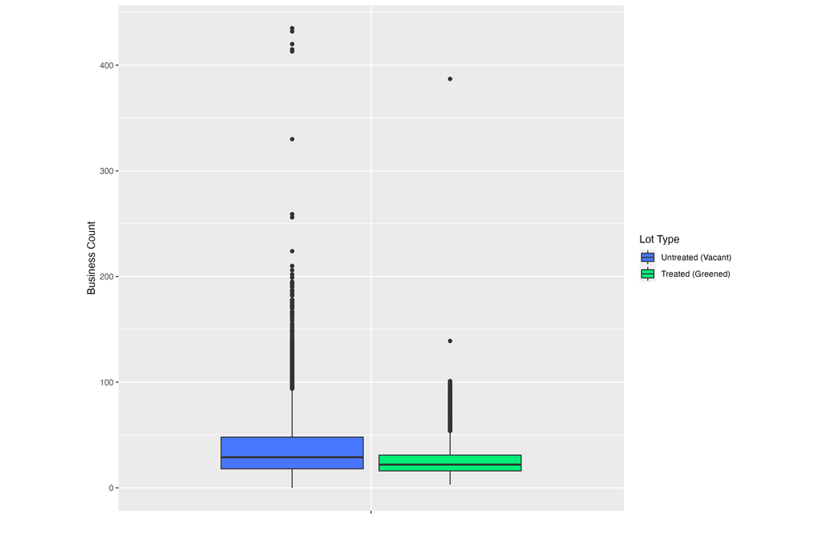

**Mostly the same**, except with scaled down business counts, as expected.

### Figure S5

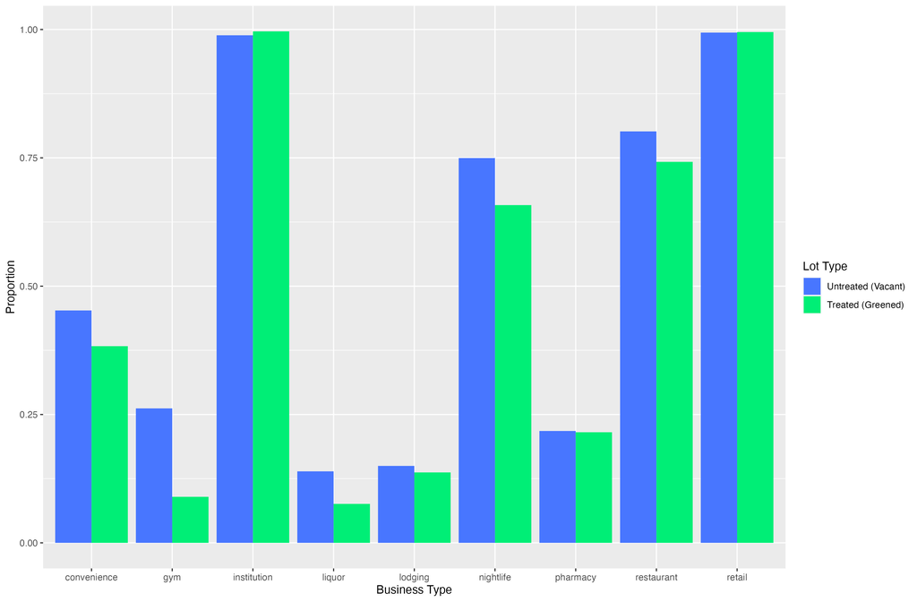

**Mostly the same**, except with scaled down proportions of business presence, as expected.

### Table S1

| Metric | All | Economic | Demographic | Land Use | Business |
| --- | --- | --- | --- | --- | --- |
| ROC AUC | 0.81 | 0.66 | 0.71 | 0.74 | 0.63 |
| Accuracy | 0.70 | 0.61 | 0.59 | 0.68 | 0.49 |
| Balanced Accuracy | 0.74 | 0.63 | 0.65 | 0.68 | 0.58 |
| Kappa | 0.35 | 0.18 | 0.20 | 0.28 | 0.10 |
| Specificity | 0.80 | 0.66 | 0.74 | 0.69 | 0.75 |
| Pos Pred Value | 0.92 | 0.86 | 0.89 | 0.89 | 0.86 |
| Neg Pred Value | 0.41 | 0.31 | 0.31 | 0.37 | 0.26 |

### Figure S6

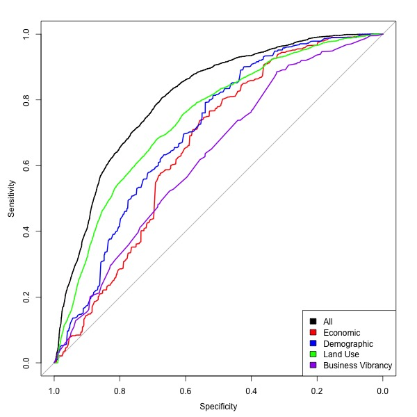

**Mostly the same**, except the “All” and “Business” curves will be sligtly different.

### Table S2

| Coefficient | Estimate | Std. Error | Stat | P-value |
| --- | --- | --- | --- | --- |
| (Intercept) | -2141.38 | 1204.98 | -1.78 | 7.55e-02 |
| Civic | 1.48 | 0.36 | 4.07 | 4.71e-05 |
| Commercial | 2142.73 | 1205.00 | 1.78 | 7.54e-02 |
| Cultural | 2145.05 | 1204.98 | 1.78 | 7.51e-02 |
| Industrial | 2139.61 | 1204.99 | 1.78 | 7.58e-02 |
| Transportation | 2141.13 | 1204.97 | 1.78 | 7.56e-02 |
| Vacant | 2149.72 | 1204.98 | 1.78 | 7.44e-02 |
| Water | 2129.93 | 1204.95 | 1.77 | 7.71e-02 |
| Residential | 2141.66 | 1204.97 | 1.78 | 7.55e-02 |
| block_total_count | 0.00 | 0.00 | 6.17 | 7.00e-10 |
| white_percent | 8.49 | 2.36 | 3.59 | 3.26e-04 |
| black_percent | 11.74 | 2.29 | 5.13 | 2.88e-07 |
| asian_percent | 10.85 | 2.43 | 4.46 | 8.15e-06 |
| hispanic_percent | 9.41 | 2.25 | 4.18 | 2.89e-05 |
| block_per_capita_income | -1.62 | 0.10 | -15.51 | 3.01e-54 |
| income_to_poverty_under_.50 | -1.99 | 0.27 | -7.36 | 1.79e-13 |
| income_to_poverty_.50_to_.99 | -0.15 | 0.25 | -0.60 | 5.46e-01 |
| income_to_poverty_1.00_to_1.24 | -2.15 | 0.34 | -6.40 | 1.53e-10 |
| income_to_poverty_1.25_to_1.49 | -1.32 | 0.33 | -4.03 | 5.47e-05 |
| income_to_poverty_1.50_to_1.84 | 1.39 | 0.32 | 4.40 | 1.09e-05 |
| income_to_poverty_1.85_to_1.99 | 0.80 | 0.36 | 2.25 | 2.46e-02 |
| cafe | -0.09 | 0.04 | -2.26 | 2.38e-02 |
| convenience | 0.13 | 0.04 | 3.18 | 1.49e-03 |
| gym | -0.62 | 0.06 | -10.05 | 9.30e-24 |
| institution | 1.83 | 0.31 | 5.94 | 2.85e-09 |
| liquor | -0.04 | 0.07 | -0.54 | 5.91e-01 |
| lodging | 0.12 | 0.06 | 2.01 | 4.43e-02 |
| nightlife | 0.04 | 0.04 | 0.98 | 3.26e-01 |
| pharmacy | 0.19 | 0.05 | 3.66 | 2.54e-04 |
| restaurant | 0.34 | 0.05 | 6.89 | 5.77e-12 |
| retail | 0.48 | 0.28 | 1.74 | 8.24e-02 |
| business_count | -0.01 | 0.00 | -6.20 | 5.52e-10 |

**Some discrepancies**, especially with the business variables. All other variables will have about the same values, and any differences are due to the changes in the business presence variables.

### Table S3

| Crime Category | Pre-Greening Crime Rate | DID Estimate | Standard Error | T-stat | p-value | DID Estimate as a % |
| --- | --- | --- | --- | --- | --- | --- |
| Serious | 5.63 | -0.0576 | 0.0748 | -0.77 | 0.441000 | -1.02 |
| Other | 19.90 | -0.5380 | 0.1600 | -3.36 | 0.000794 | -2.70 |
| Total | 25.60 | -0.5960 | 0.1870 | -3.19 | 0.001410 | -2.33 |

Described in the explanation of Table 1.

### Table S4

| Crime Category | Pre-Greening Crime Rate | DID Estimate | Standard Error | T-stat | p-value | DID Estimate as a % |
| --- | --- | --- | --- | --- | --- | --- |
| Serious | 117 | -3.51 | 0.337 | -10.4 | 4.08e-25 | -2.99 |
| Other | 452 | -15.70 | 1.070 | -14.8 | 3.76e-48 | -3.48 |
| Total | 569 | -19.20 | 1.210 | -15.9 | 1.03e-55 | -3.38 |

Described in the explanation of Table 1.